# W3cubDocs

/Chef 18

# Chef Infra Server

[[edit on GitHub]](https://github.com/chef/automate/blob/master/components/docs-chef-io/content/automate/chef_infra_server.md)

## Overview

The *Chef Infra Server* page (**Infrastructure > Chef Servers**) lets you connect existing Chef Infra Servers to Chef Automate, view all the connected Chef Infra Servers, and manage all of the objects on your connected Chef Infra Servers.

The *Chef Infra Server* acts as a hub for configuration data. The Chef Infra Server stores *cookbooks*, the policies that are applied to *nodes*, and metadata that describes each registered node managed by Chef Infra Client.

Nodes use Chef Infra Client to ask the Chef Infra Server for configuration details, such as recipes, templates, and file distributions. Chef Infra Client then does as much configuration work as possible on the nodes themselves (and not on the Chef Infra Server).

This scalable approach distributes the configuration effort throughout the organization.

[figure not shown]

The objects that you can manage from the Chef Infra Server are:

- Cookbooks
- Roles
- Environments
- Data Bags
- Clients
- Nodes
- Policyfiles
- PolicyGroup

## Connect Chef Infra Servers to Chef Automate

The *Chef Infra Server* panel starts with an empty list of servers.

To add existing Chef Infra Servers to the Chef Automate infrastructure, select **Add Chef Server**, which will request the name, FQDN, and IP address of your Chef Infra Server:

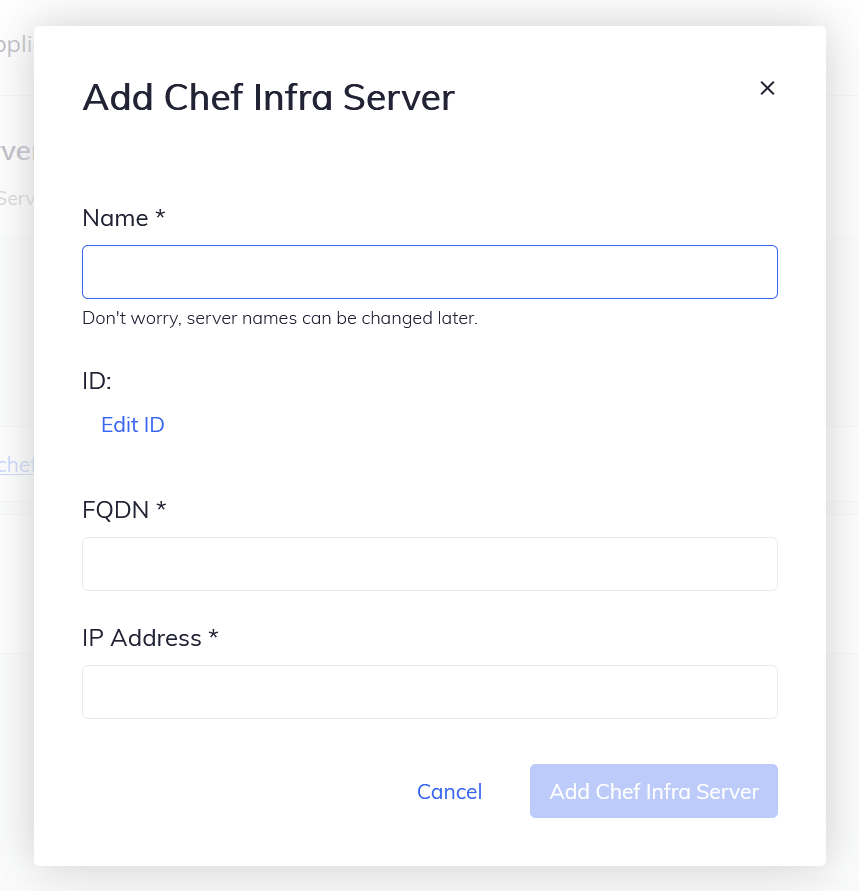

Chef Automate warns you if you enter an invalid FQDN or IP address:

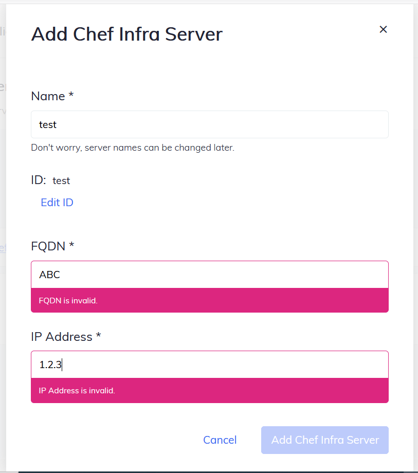

Once done, select **Add Chef Server** and see the server in the list of Chef Infra Servers.

## Connect a Chef Organization to a Chef Infra Server

To view a list of existing organizations on a Chef Infra Server, select a Chef Infra Server from the **Chef Servers** list, then select the **Organizations** tab, as shown below:

[figure not shown]

To create a new organization, see the documentation on setting up a Chef Infra Server.

To add an existing organization, select **Add Chef Organization**, which opens a dialog box as shown below:

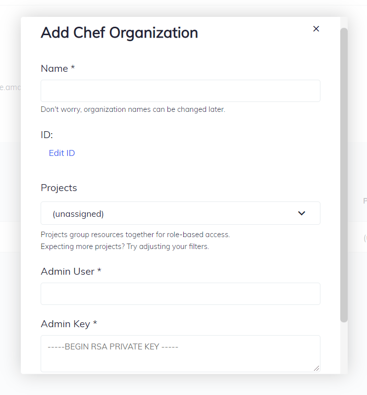

Enter the *Name*, *Projects*, *Admin User*, and *Admin Key* fields using the same values provided when the organization gets configured using *Knife*. Copy the contents of the `~/.chef/USER.pem` file and paste it into the **Admin Key** field. Then select **Add Chef Organization** to add the organization to the Chef Infra Server.

## Access Chef Infra Server Components

Manage the following Chef Infra Server components for an organization using Chef Automate:

- Cookbooks
- Roles
- Environments
- Data Bags
- Clients

To access these components for an organization, select **Chef Servers > Organizations** and then select an organization. Refer to the image below:

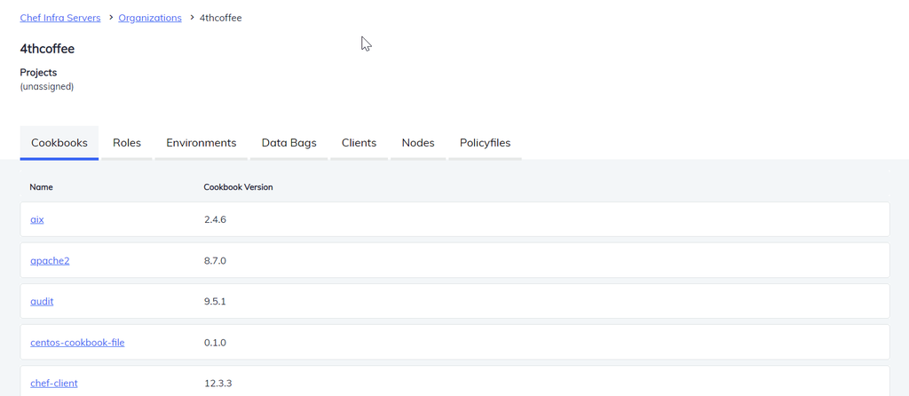

### Cookbooks

A cookbook is the fundamental unit of configuration and policy distribution. A cookbook contains recipes and other files, components, or directories.

The Chef Infra Server lets you view:

- List of cookbooks with their latest version
- Different versions of a cookbook
- Contents of a cookbook
- Details of a cookbook

#### List of Cookbooks

In Chef Infra Server, you can view all the cookbooks of an organization. The latest version of the cookbooks is mentioned in the list.

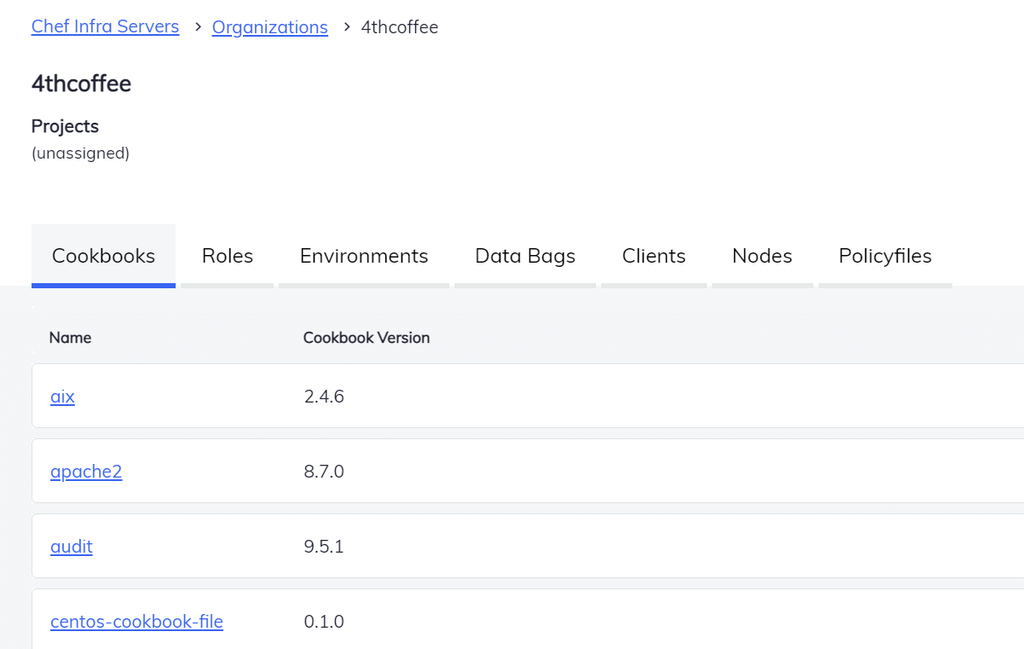

Select a cookbook from the list to view the details of that cookbook.

#### Different Versions of Cookbooks

To view different versions of a cookbook:

- Select a cookbook from the list.
- View the different versions of the cookbook using the dropdown list.

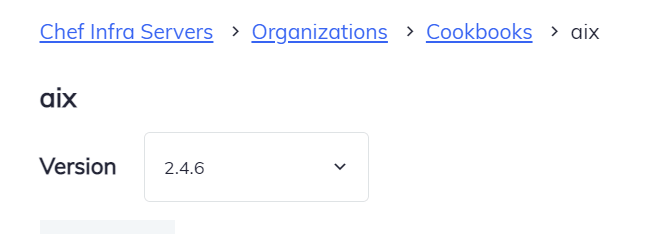

#### Cookbook Content

Select the **Content** tab to view the recipes and other components of a cookbook. This view also contains the files or directories of the components. To view the cookbook content, select the file from the component list.

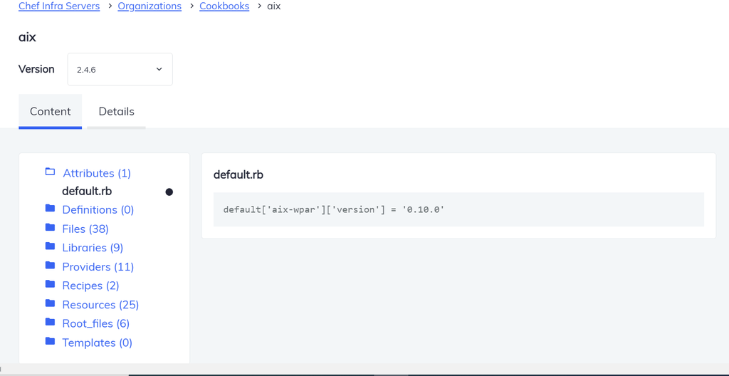

#### Details of a Cookbook

Select the **Details** tab to view the requirements, usage, resources, and license.

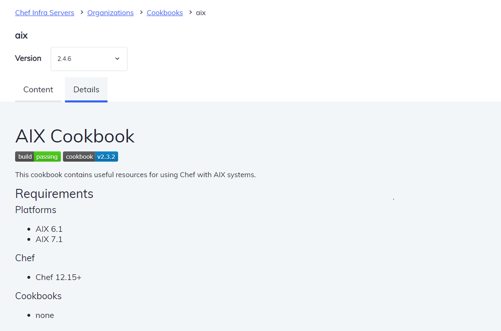

### Roles

Roles let you define patterns and processes that exist across nodes in an organization as belonging to a single job function. Each role consists of zero (or more) attributes and a run-list.

The Chef Infra Server lets you:

- Create a role
- View all roles
- Search for a specific role
- View the details of roles:
  - Run List
  - Attributes
- Delete a role

#### Create a Role

To create a new role, select **Create Role**:

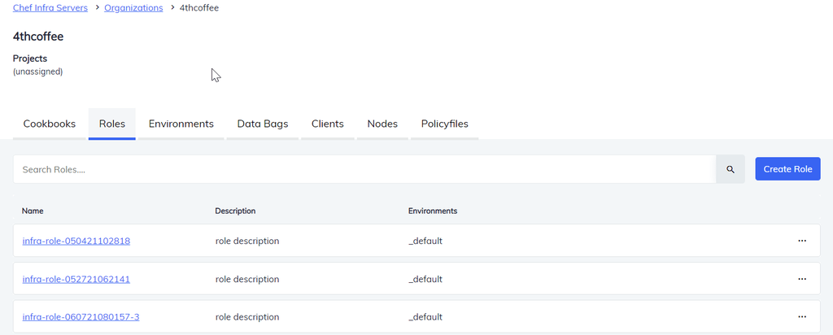

Selecting the **Create Role** button opens a dialog box. The dialog box contains four sections: *Details*, *Run List*, *Default Attributes*, and *Override Attributes*. Enter the details in the possible sections and select **Create** to create a new role.

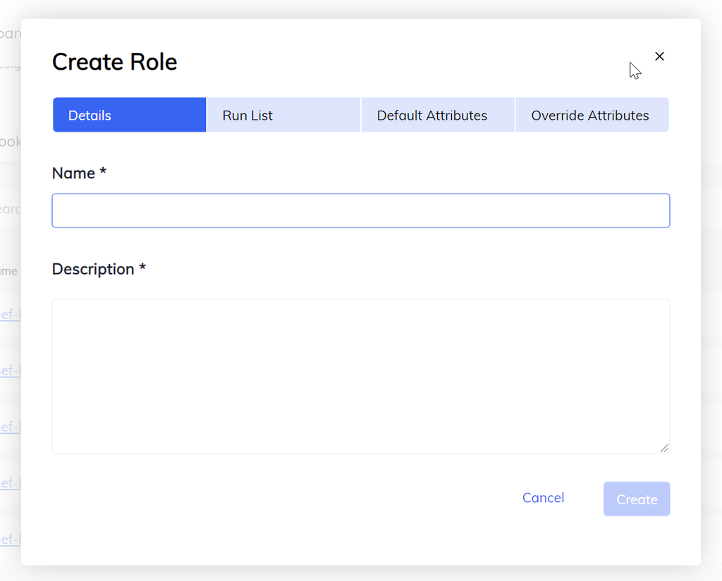

#### Search for a Role

Use the **Search Roles** bar to find the existing role from the list of roles. Entering the name of a role in the search box returns roles matching your search criteria.

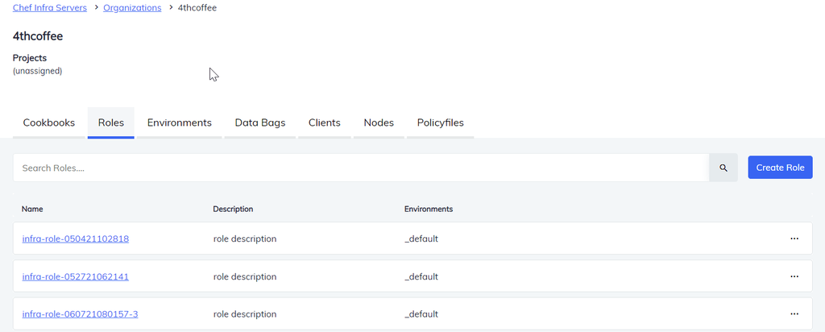

#### View Role Details

Select a specific role to view the details of that particular role. It contains two tabs, *Details* and *Attributes*.

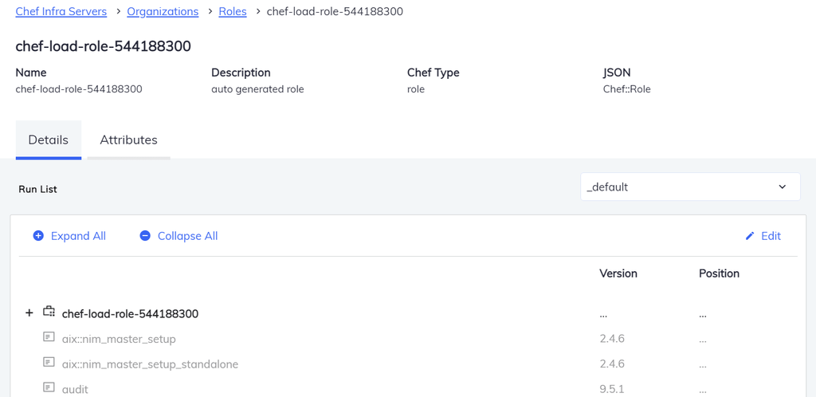

The *Details* contains the Run List, whereas the attributes tab displays the *default* and the *override* attributes of the role.

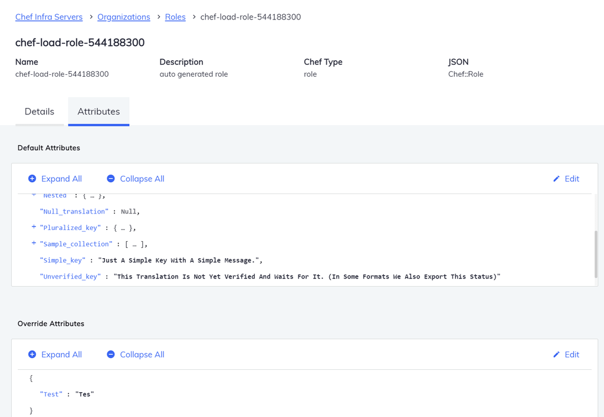

You can edit the *default* and *override* attributes by selecting the **Edit** option. It opens a pop-up window where you can make the changes and select **Save**.

#### Delete a Role

Chef Infra Server lets you delete the existing roles one at a time. To delete a role, select the ellipses icon and then **Delete**, as illustrated below:

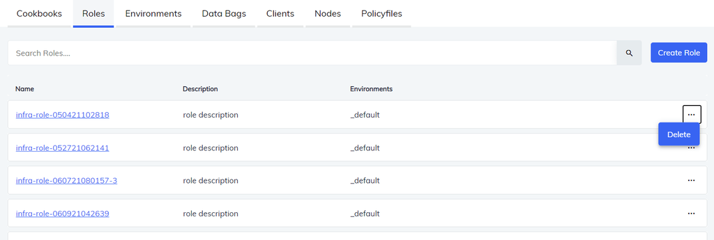

### Environments

An environment can be used to map an organization’s real-life workflow to what can be configured and managed when using Chef Infra. This mapping is accomplished by setting attributes and pinning cookbooks at the environment level.

The Chef Infra Server UI lets you:

- Create an environment
- View all environments
- Search for a specific environment
- View the details of an environment
- Edit an environment
- Delete an environment

#### Create an Environment

To create a new Environment, select **Create Environment**, as shown below:

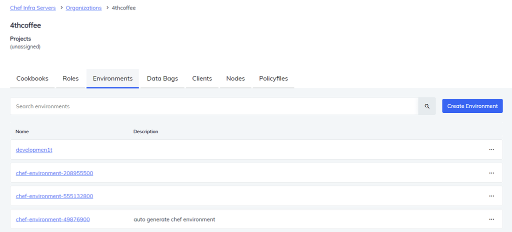

Selecting the **Create Environment** button opens a dialog box. The dialog box contains four sections: *Details*, *Constraints*, *Default Attributes*, and *Override Attributes*. Enter the details in the possible sections, and select **Create** to create a new environment.

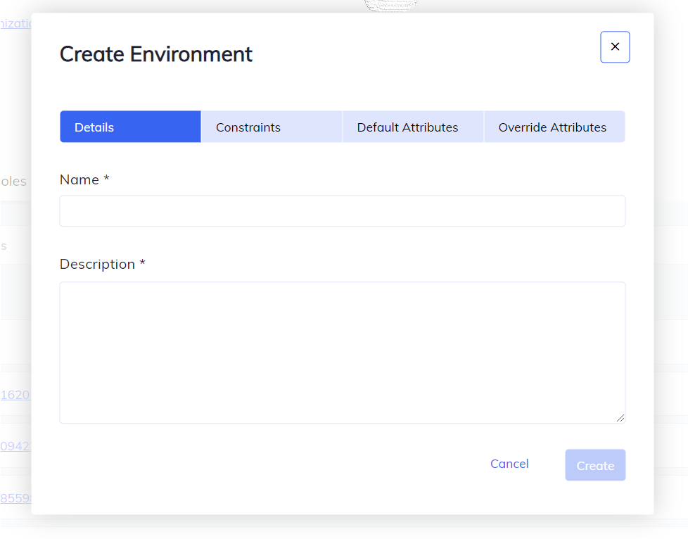

#### Search for an Environment

Use the **Search environments** bar to find an existing environment from the list. Entering the name of an environment in the search box returns environments matching your search criteria.

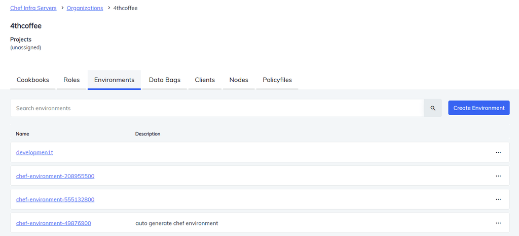

#### Details of an Environment

Select a specific environment to view that environment’s cookbook constraints and attributes.

##### Cookbook Constraints

The selected bar contains the list of all the cookbook constraints with *Name*, their *Operator*, and *Version* respectively. Select **Edit** to change the *Cookbook Constraints*.

[figure not shown]

##### Attributes

The attributes window shows all the default and overridden attributes. Select **Expand All** or **Collapse All** to view or hide the attributes. Select **Edit** to change the *Default Attributes* and *Override Attributes*.

Note

You can edit *Cookbook Constraints* and the *Attributes* only for environments with an existing *client* for that *organization*.

[figure not shown]

#### Delete an Environment

The Chef Infra Server lets you delete environments one at a time. Select **Delete** from the more information (three dots) icon on the far right side of the environment that you want to delete, as shown below:

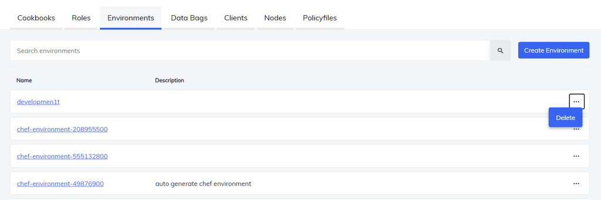

### Data Bags

Data bags store global variables as JSON data. Data bags are indexed for searching and can be loaded by a cookbook or accessed during a search.

Chef Infra Server UI lets you:

- Create a data bag
- View all data bags
- Search for a specific data bag item
- Create a data bag item
- Edit a data bag item
- Delete a data bag item
- Delete a data bag

#### Create a Data Bag

To create a new data bag, select **Create Data Bag**, as shown below:

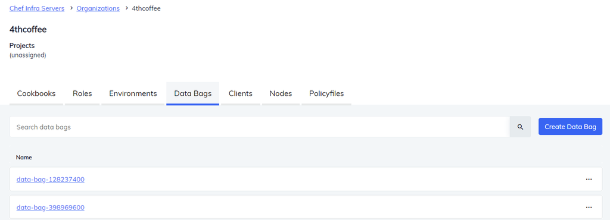

Selecting the **Create Data Bag** button opens a dialog box. Enter the name and select **Create**.

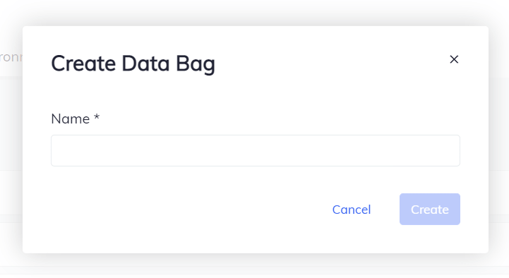

#### Create a Data Bag Item

To create a data bag item, select the data bag from the list of data bags and follow the steps given below:

Select **Create Item**, as shown below:

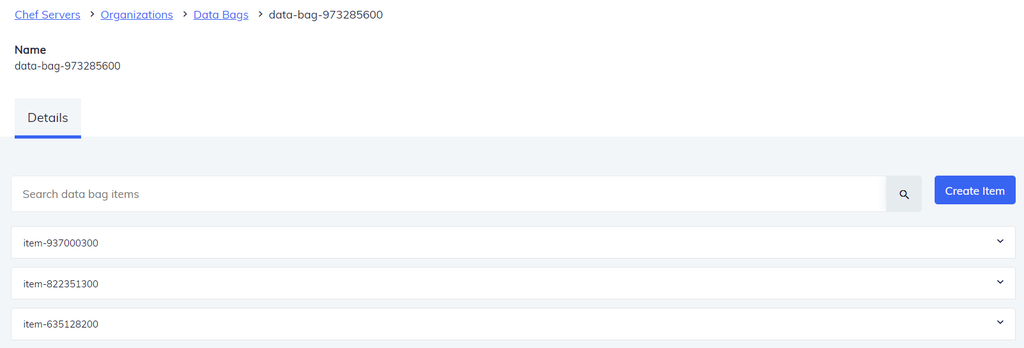

Selecting the **Create Item** button opens a dialog box. Enter the **Data Bag Item ID** and the details of the key value pairs of that particular item. Select **Create**.

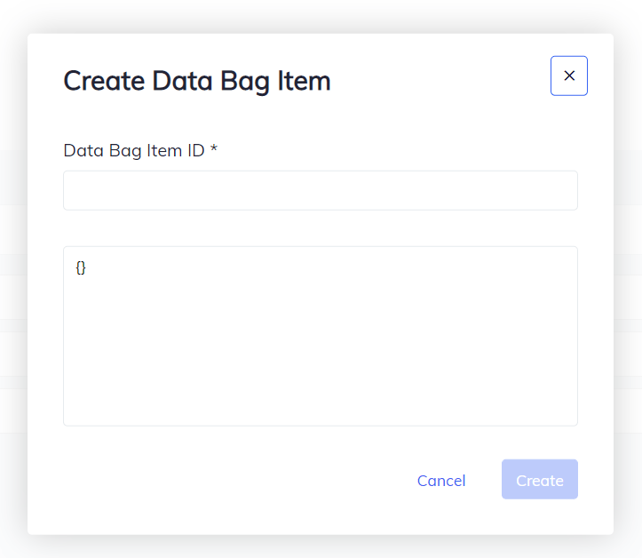

#### Search for an Item

Use the **Search data bag items** bar to find an item from the list of data bag items. Entering the name of an item in the search bar returns data bag items that match your search criteria.

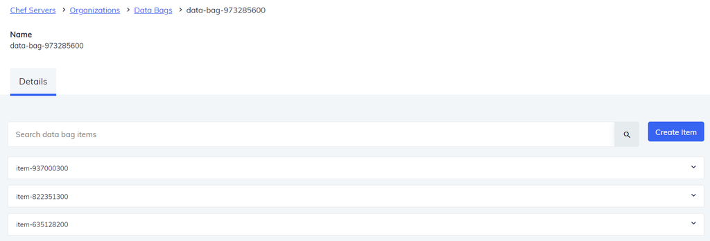

#### Edit a Data Bag Item

Select a specific data bag item to view the details. The details contain an *id*, and a couple of *key values*. Chef Infra Server lets you **edit** a data bag item.

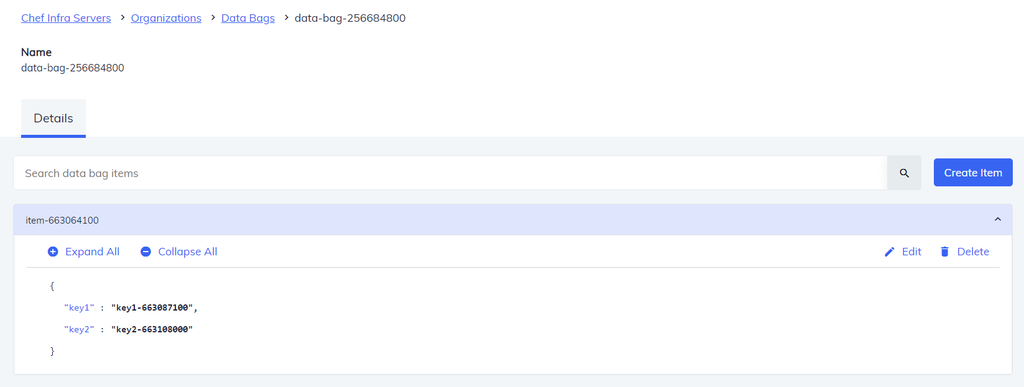

To edit the details of the data bag items, select **Edit**. In the dialog box, you can edit the details for the specific data bag item. Once done, select **Save Item**.

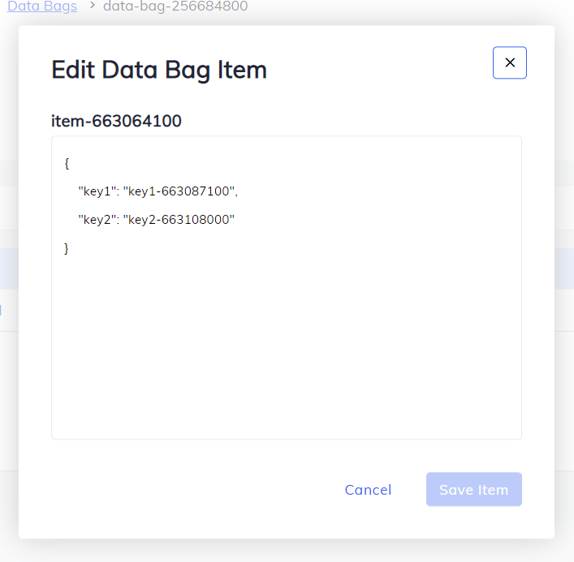

#### Delete a Data Bag Item

Select a specific data bag item to view the details. The details contain an *id* and a couple of *key values*. Chef Infra Server lets you **delete** a data bag item.

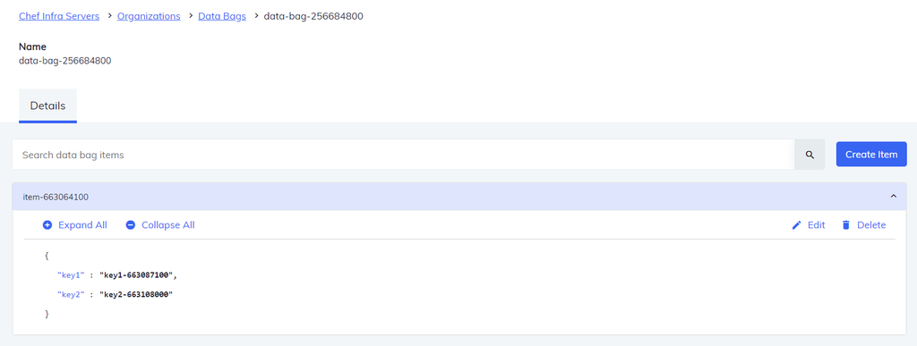

To delete a data bag item, select **Delete**. In the dialog box displayed, select **Delete** to delete the data bag item.

[figure not shown]

#### Delete a Data Bag

Chef Infra Server lets you delete the existing data bag one at a time. To delete a data bag, select the ellipses icon and then **Delete**, as illustrated below:

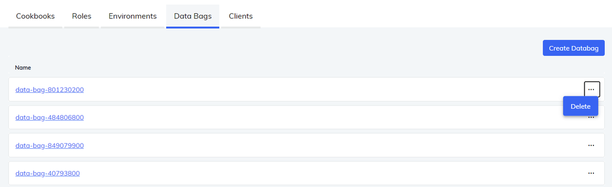

### Clients

Chef Infra Clients provide secure API access to the Chef Infra Server. Chef Infra Server UI lets you:

- Create a client
- View all clients
- Search for a specific client
- Reset a client key
- Delete a client

#### Create a Client

To create a new client, select **Create Client**.

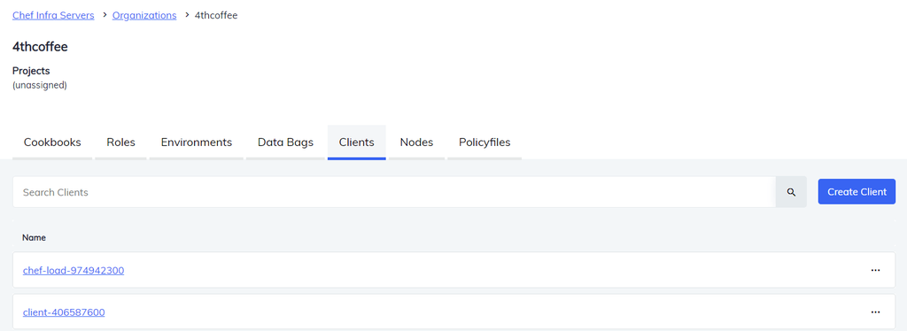

The **Create Client** button opens a dialog box. Enter the *Client Name* and select *Validation Client* to create a Validation Client. Select **Create**.

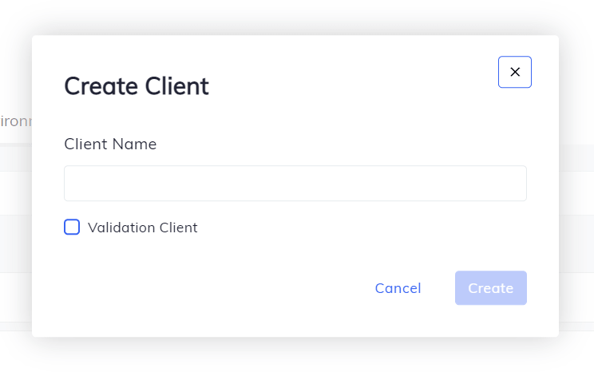

Selecting **Create** opens a dialog box that contains the *Private Key* of that particular client. Select **Download** to download the *Private Key*.

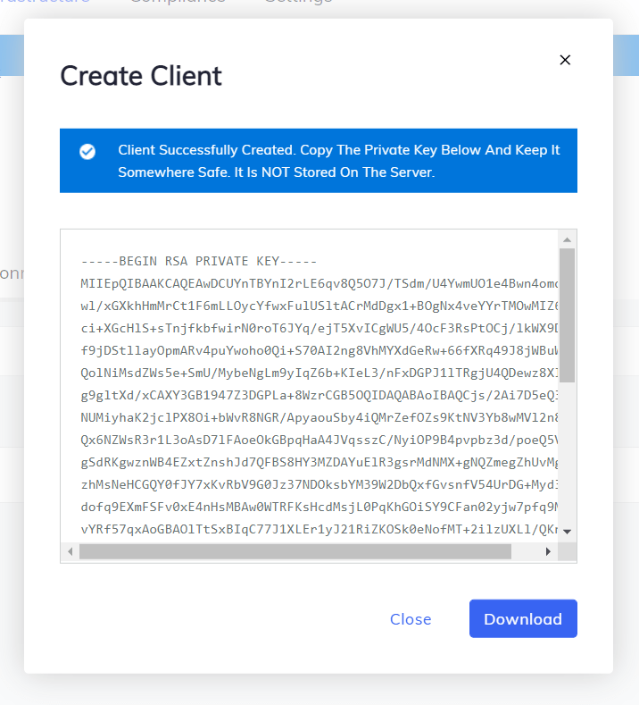

#### Search for a Client

Use the **Search Clients** bar to find a client from the list of clients. Entering the name of a client in the search bar returns clients matching your search criteria.

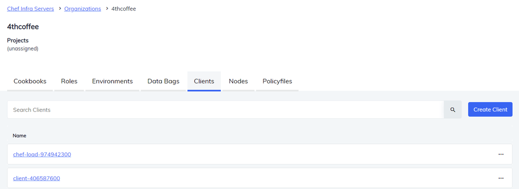

#### Public Key of a Client

Select the client to view the *Public Key* for that client. The *Public Key* of that client will be displayed in **Details**.

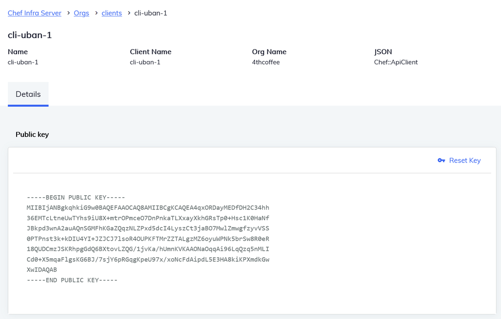

The Chef Infra Server lets you reset the *Public Key* using the *Reset Key* option. Selecting the *Reset Key* option opens an alert stating *The current key will no longer be accepted.*

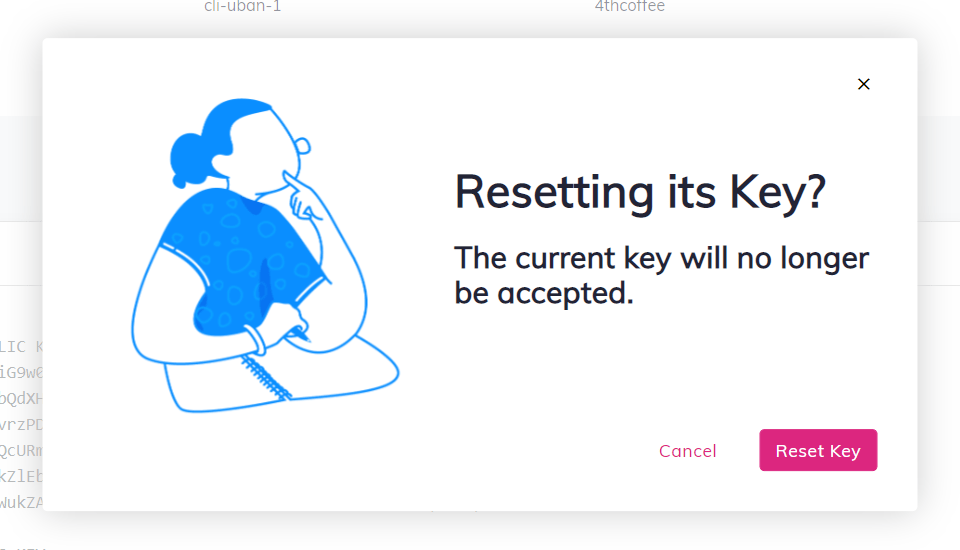

Selecting the *Reset Key* shown in the above image opens a new dialog box containing the client’s new *Private Key*. To download the new *Private Key*, select **Download**.

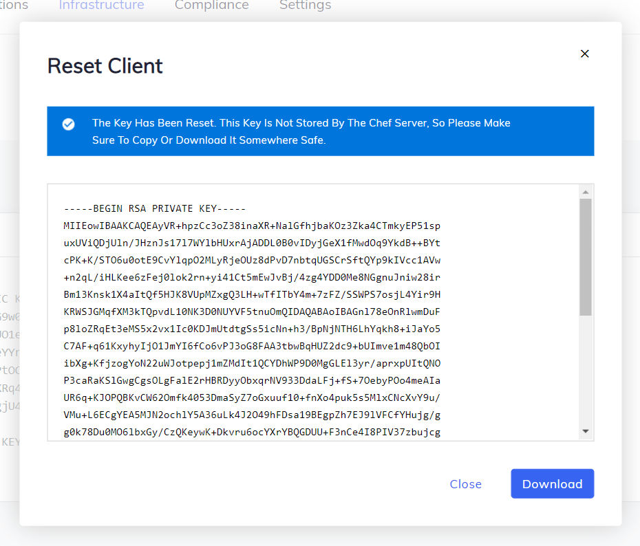

#### Delete a Client

Chef Infra Server lets you delete the existing clients one at a time. To delete a client, select the ellipses icon and then **Delete**, as illustrated below:

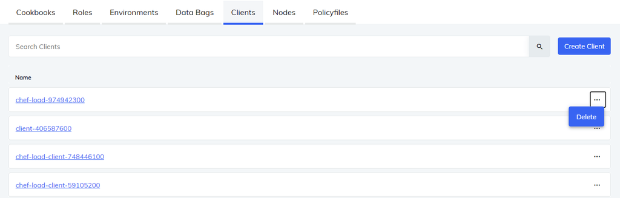

### Nodes

A node is a device that is managed by Chef Infra. During the Chef Infra Client run, the Infra Client retrieves attributes that defines the expected state of the node and a run-list that defines how a node can be configured to that state from the Infra Server. The Infra Client then uses that information to update the node to its expected state.

The Chef Infra Server integration lets you:

- Search for a specific node
- View all nodes
- Details of a node
- Edit Run list
- Edit Attributes
- Manage tags
- Reset a node key
- Delete a node

#### Search for a Node

Use the search bar on the Nodes tab (**Chef Infra Servers > Nodes**) to find a node from the list of nodes. Entering the name of a node in the search bar returns nodes matching your search criteria.

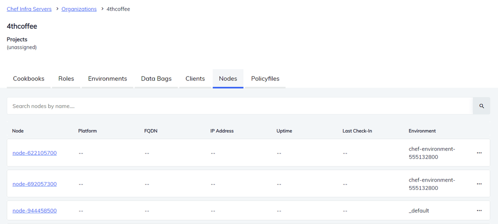

#### Details of a Node

Select a specific node to view the node information, metadata, and details of the node’s environment. The first section of the page has the **Node Information** like `Environment`, `Policy Group`, and `Policy Name`. You can also view the **Metadata** for the node that contains the name of the `Chef Server`, and the name of the `Chef Organization`.

The above information looks like as shown below:

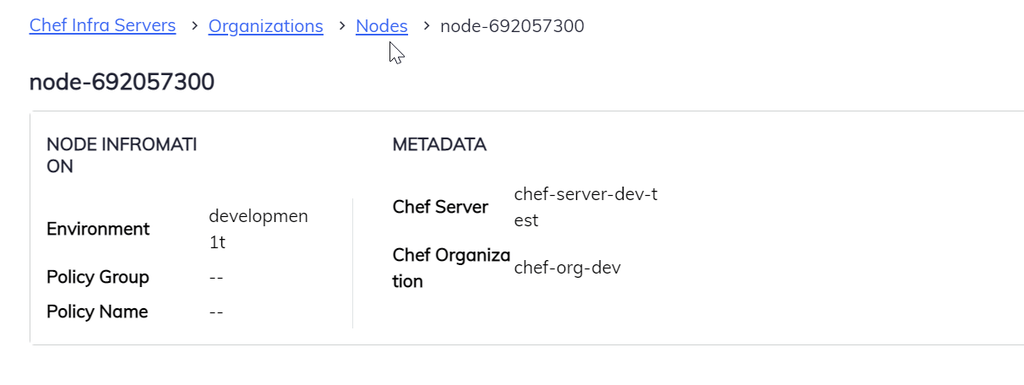

- Details
- Run List
- Attributes

##### Details

The **Details** section lets you view and update the node environment. The drop-down menu consists of the list of environments created in the chef server. You can select any one environment for the selected node.

To select the environment:

- Select the dropdown menu and the name of the environment.
- You can add tags to the environment from the text bar below the dropdown menu. **Note:** To add multiple tags at a time, use a comma separator. Example: Tag1, Tag2, Tag3.
- Selecting an environment opens a pop-up to save the node environment. Select **Save** to change the node environment.

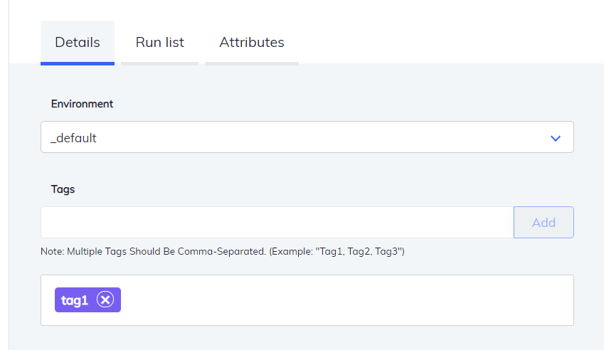

##### Run List

You can edit, expand or collapse a node’s run list.

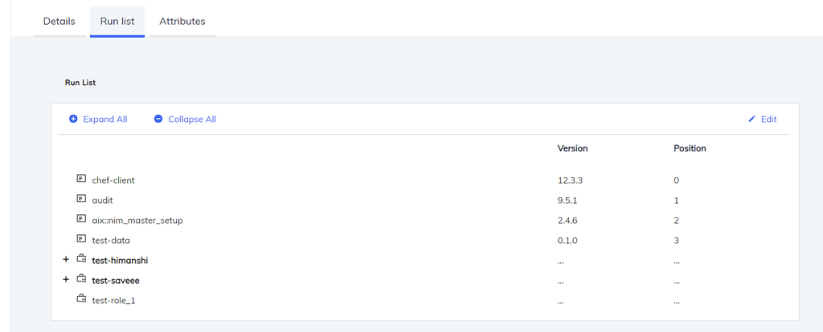

Edit a run list by:

1. Select **edit**. A pop-up window opens.
2. The left side of the window contains the list of environments. Select an environment from the list.
3. The right side of the window shows the run list for the selected environment.
4. Select the run list for a specific environment.
5. Select **Create**.

This opens a pop-up window similar to:

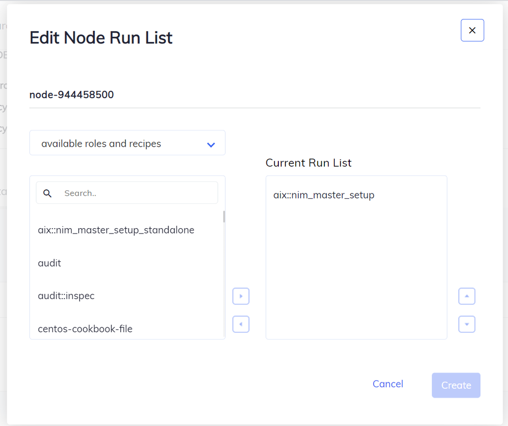

You can find the editing window directly by selecting the ellipses icon and then **Edit Run List** of a specific node in the node list. Selecting the option opens a pop-up for editing the run list.

##### Attributes

The attributes window shows all the default and overridden attributes. Select **Expand All** or **Collapse All** to view or hide the attributes. Select **Edit** to change or update the existing attributes.

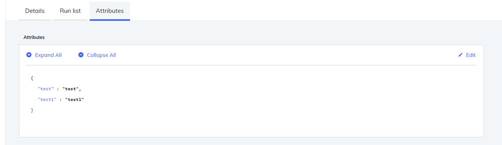

You can find the editing window directly by selecting the ellipses icon and then **Edit Attributes** of a specific node in the node list. Selecting the option opens a pop-up for editing the attributes.

#### Manage Tags

Chef Infra allows you to manage tags of the environment. You can add or remove multiple tags in two ways:

1. Selecting the node and add the tags from the text bar below the dropdown menu of environments.
2. Select the ellipses icon and then **Manage Tags** for a specific node. Add and remove tags in tag editor and select **Update Tags** to save your changes.

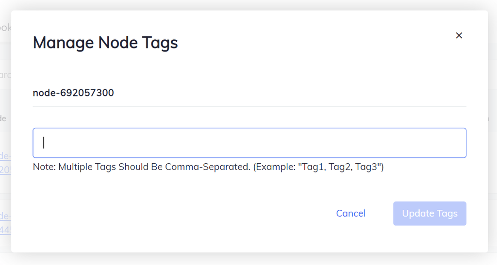

#### Reset a Client Key

Reset a client key by selecting the ellipses icon and then **Reset Key** of a specific node in the node list. Selecting **Reset Key** opens a warning *The current key will no longer be accepted*. Select **Reset Key** once again to confirm.

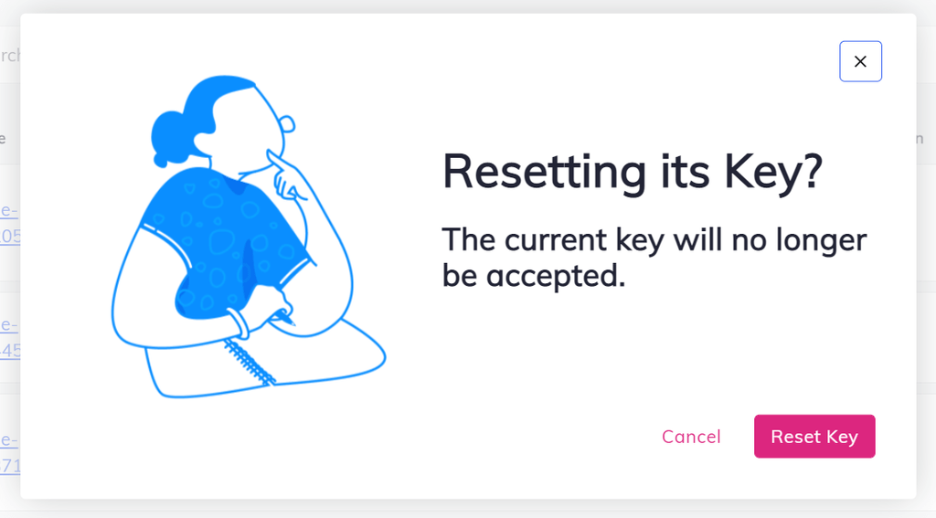

#### Delete a Node

Delete individual existing nodes by selecting the ellipses icon and then **Delete**:

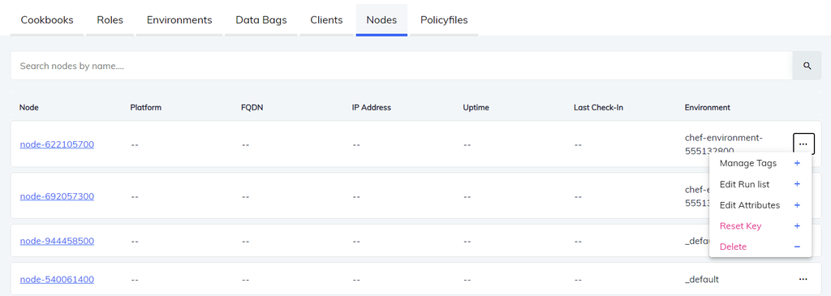

### Policyfiles

Policyfiles are preferred way of managing roles, environments, and community cookbooks data with a single document that is uploaded to the Chef Infra Server. Policyfiles lets you test and promote codes with a simpler interface.

The Chef Infra Server integration lets you:

- Search for specific Policyfiles
- View all the Policyfiles
- View the details of Policyfiles:
  - Content
  - Attributes
  - Revision ID
- Delete Policyfiles

#### Search for Policyfiles

Use the search bar on the Policyfile tab (**Chef Infra Server > Policyfile**) to find a policy file from the list. Enter the name of a policy file in the search bar to view matching Policyfiles.

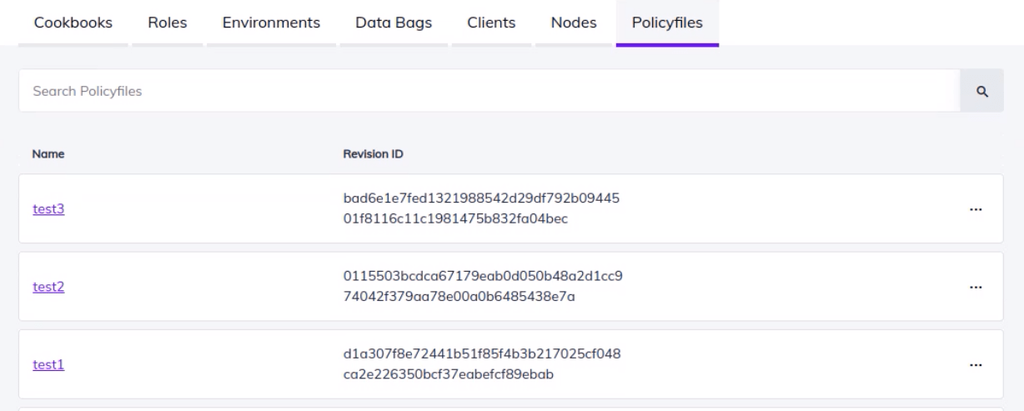

#### Details of Policyfiles

Select a Policyfile to view the **METADATA**, **Content**, **Attributes**, **Revision ID**, and **Cookbook Dependencies** of that Policyfile.

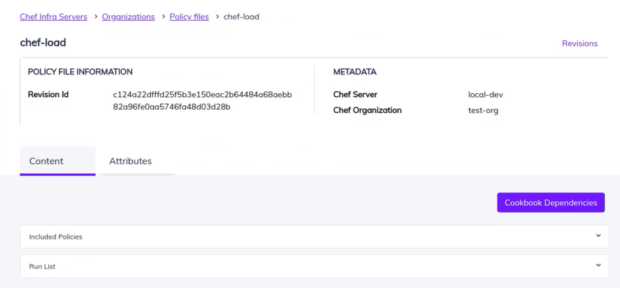

##### Content Tab

The **Content** tab contains the list of all:

- Included Policies
- Run Lists

###### Included Policies

Select a specific Policyfile from the *Included Policies* to view the details.

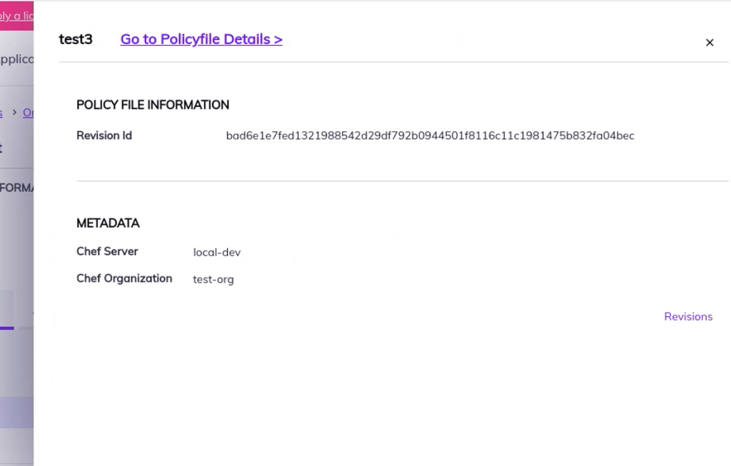

In the above image, the slider tab shows the *Details* of the selected policyfile. To view the *Revision ID* select the **Revisions** option in the tab.

###### Run List

Select a specific Run Item from the Run List to view the details in a slider tab.

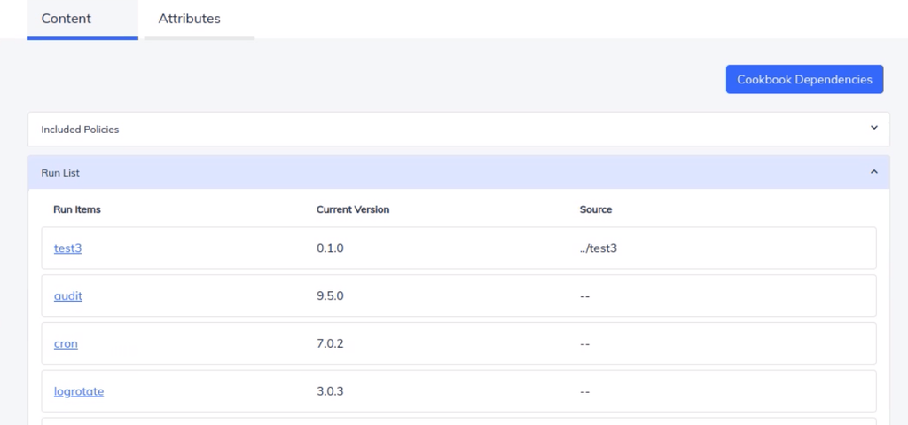

To view the cookbook details of the item, select the **Go to Cookbook Details** option in the tab.

##### Attributes Tab

The **Attributes** tab displays the *default* and the *override* attributes of a Policyfile.

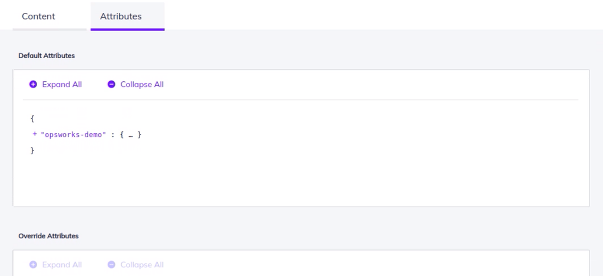

You can **Expand** and **Collapse** the *default* and *override* attributes by selecting the option.

##### Cookbook Dependencies

Select the **Cookbook Dependencies** button to view all the *Dependencies Rules* and *Cookbook* of the policyfile in table format. Select a specific cookbook from the list to view the details of the cookbook.

Note

The slider tab contains the `Operator` and `Version` of the cookbooks.

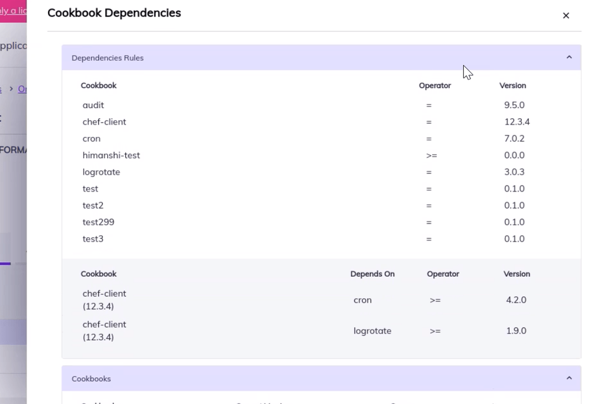

Note

You can find the **Revision ID** window directly by selecting the ellipses icon of a Policyfile. Selecting the option opens a pop-up that contains the detailed revision ID.

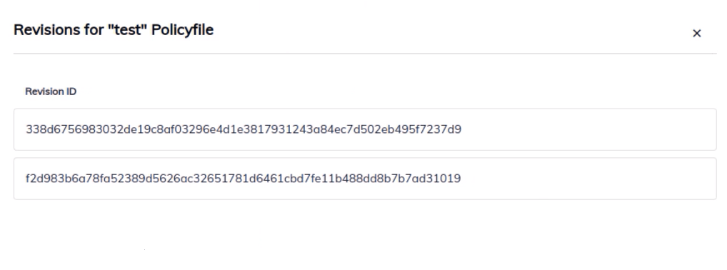

#### Delete Policyfiles

Delete individual Policyfiles by selecting the ellipses icon and then **Delete**:

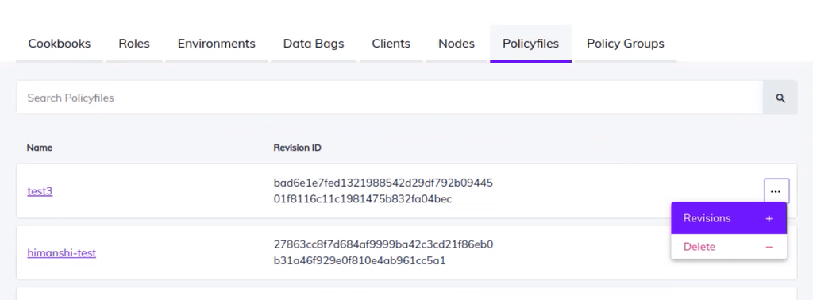

### Policy Group

The Chef Infra Server integration lets you:

- Search for a Policy Group
- View all the Policy Groups
- View the details of a Policy Group
  - Policyfiles
  - Nodes

#### Search for a Policy Group

The search bar on the Policy Groups tab (**Chef Infra Server > Policy Groups**) finds a policy group from the list. Enter the name of a policy group in the search bar to view matching Policy Groups.

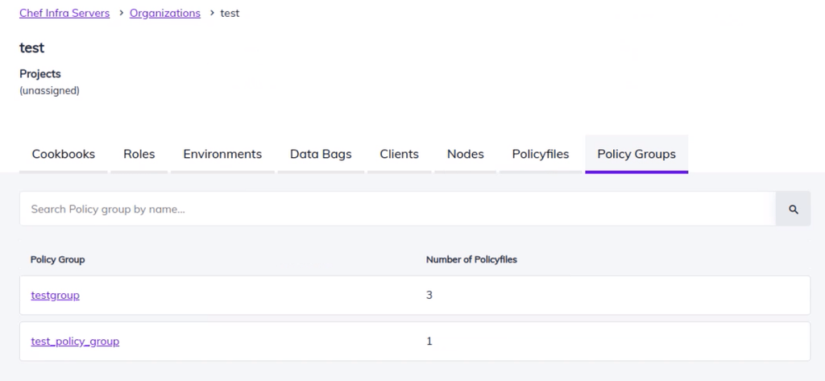

#### View the details of a Policy Group

Select a Policy Group to view the Policy Group Information and METADATA of that Policy Group.

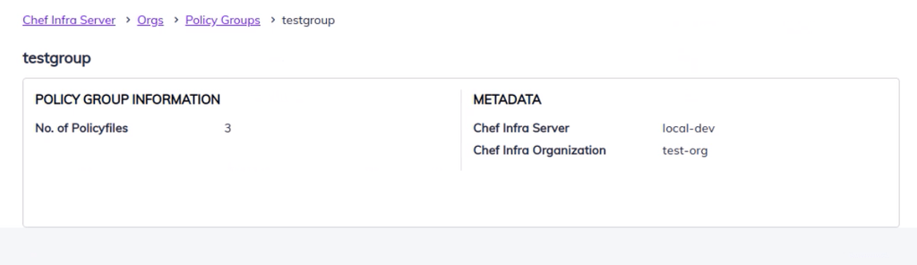

##### Policyfiles Tab

The details page of the policy group view the list of **Policyfiles**.

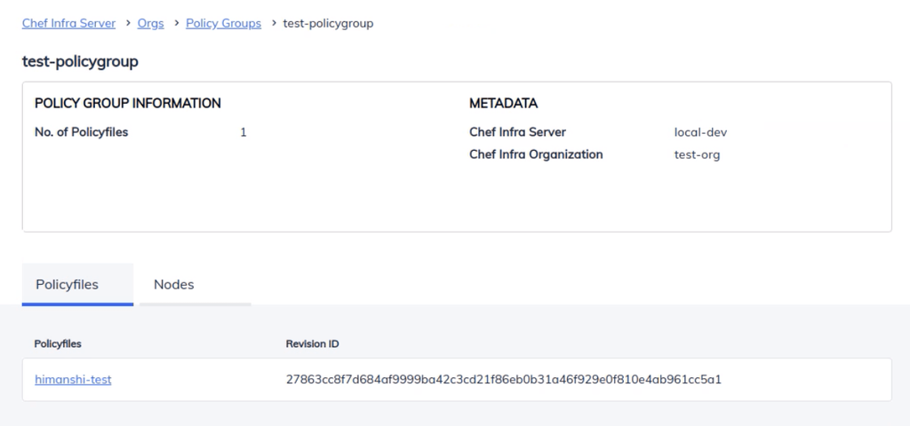

Select a Policyfile from the list to view its details.

Note

Selecting a specific policyfile redirects you to the details section of the **Policyfiles** main tab.

##### Nodes Tab

The details page of the policy group lets you view the list of **Nodes**.

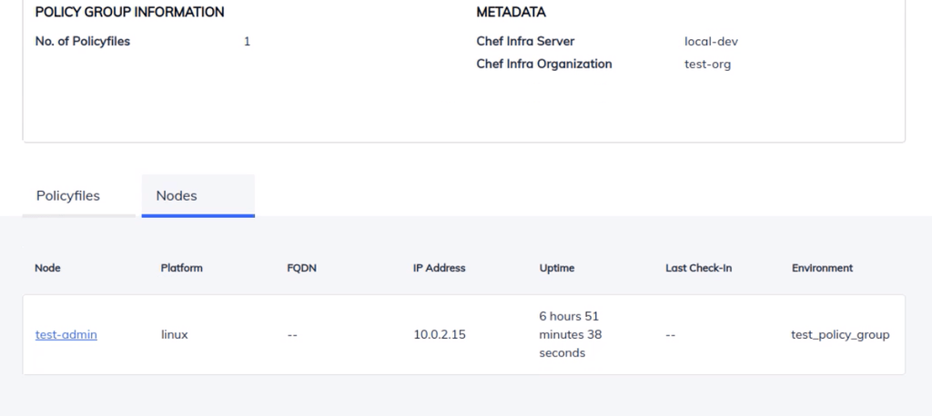

Select a node from the list to view its details

Note

Selecting a specific node opens details section of the **Nodes** tab.

## Troubleshoot

While fetching any objects like cookbooks, you might face an error `Could not get cookbooks: organization 'no-org' does not exist`, which means the provided organization does not exist on Chef Infra Server.

[figure not shown]

Create the organization using the knife command, `knife opc org create` or the Chef Infra Server CLI command, `chef-server-ctl org-create`, then add the *Name*, *Projects*, *Admin User*, and *Admin Key* to fetch the objects.